# Final Project Task 1 - Data Collection and Overfitting

## Step 1: Import the required Python libraries

```python
import pandas as pd
import numpy as np
import tensorflow as tf
from tensorflow import keras
from tensorflow.keras import layers, regularizers
from tensorflow.keras.layers import BatchNormalization, Dropout, Conv1D, MaxPooling1D, Flatten, SimpleRNN, GRU, Bidirectional
from tensorflow.keras.metrics import RootMeanSquaredError
from tensorflow.keras.callbacks import ModelCheckpoint, EarlyStopping
from matplotlib import pyplot as plt
from sklearn.preprocessing import MinMaxScaler                      # For normalizing the data.
from scipy.interpolate import interp1d                              # For applying Time Warping augmentation technique to a model.
```

## Step 2: Collect the time-series data for Bitcoin

### **2.1: Upload the Bitcoin dataset saved on Google Drive**

The series of models that will be created will rely on a dataset called **BTC_USD.csv**. The dataset contains several different features (columns) that include day-to-day data over the course of 5 years **(5/3/2019 to 5/3/2024)**:

> 1.) Open Price

> 2.) High Price

> 3.) Low Price

> 4.) Close Price

> 5.) Adjusted Close Price

> 6.) Volume

**Source citation:**

Yahoo! (2024, May 3). *Bitcoin USD (BTC-USD)*. Yahoo! Finance. https://finance.yahoo.com/quote/BTC-USD/history/?guccounter=1&period1=1556841600&period2=1714767878

### **2.2: Determine whether the Bitcoin dataset connection is proper**

It is important to verify that the BTC_USD dataset is connected to the Google Colab notebook before proceeding. A Linux command **ls -l [filepath]** conducts this verification.

```python
! ls -l /content/drive/MyDrive/BTC_USD/
```

```
total 312
-rw------- 1 root root 159031 Mar  6 22:40 all_data.csv
-rw------- 1 root root  32296 Mar  6 22:40 test_data.csv
-rw------- 1 root root  94660 Mar  6 22:40 training_data.csv
-rw------- 1 root root  32158 Mar  6 22:40 validation_data.csv
```

### **2.3: Visualize the Bitcoin dataset**

**Tabular data for Bitcoin prices in the *first* week**

As mentioned below, the **BTC_USD.csv** dataset spans over the previous 5 years of Bitcoin's existence. The table below illustrates the *first* week of this 5-year period (5/3/2019 to 5/9/2019):

```python
alldata = pd.read_csv("/content/drive/MyDrive/BTC_USD/all_data.csv", names = ['Date', 'Open', 'High', 'Low', 'Close', 'Adj Close', 'Volume'])

alldata.iloc[1:8]
```

|  | Date | Open | High | Low | Close | Adj Close | Volume |
| --- | --- | --- | --- | --- | --- | --- | --- |
| 1 | 2019-05-03 | 5505.552246 | 5865.881836 | 5490.201660 | 5768.289551 | 5768.289551 | 18720780006 |
| 2 | 2019-05-04 | 5769.202637 | 5886.893555 | 5645.469238 | 5831.167480 | 5831.167480 | 17567780766 |
| 3 | 2019-05-05 | 5831.068359 | 5833.862793 | 5708.035156 | 5795.708496 | 5795.708496 | 14808830723 |
| 4 | 2019-05-06 | 5791.693359 | 5802.957520 | 5653.687500 | 5746.807129 | 5746.807129 | 15737171804 |
| 5 | 2019-05-07 | 5745.599121 | 5988.178223 | 5741.395996 | 5829.501465 | 5829.501465 | 18026409033 |
| 6 | 2019-05-08 | 5849.481445 | 5989.980957 | 5794.715820 | 5982.457520 | 5982.457520 | 15320605300 |
| 7 | 2019-05-09 | 5982.316406 | 6183.039063 | 5982.316406 | 6174.528809 | 6174.528809 | 16784645411 |

**Tabular data for Bitcoin prices in the *previous* week**

This table illustrates the *most recent* week of Bitcoin's pricing. The time period ranges between 4/27/2024 to 5/3/2024.

```python
alldata = pd.read_csv("/content/drive/MyDrive/BTC_USD/all_data.csv", names = ['Date', 'Open', 'High', 'Low', 'Close', 'Adj Close', 'Volume'])

alldata.tail(7)
```

|  | Date | Open | High | Low | Close | Adj Close | Volume |
| --- | --- | --- | --- | --- | --- | --- | --- |
| 1822 | 2024-04-27 | 63750.988281 | 63898.363281 | 62424.718750 | 63419.140625 | 63419.140625 | 19530783039 |
| 1823 | 2024-04-28 | 63423.515625 | 64321.484375 | 62793.597656 | 63113.230469 | 63113.230469 | 17334827993 |
| 1824 | 2024-04-29 | 63106.363281 | 64174.878906 | 61795.457031 | 63841.121094 | 63841.121094 | 26635912073 |
| 1825 | 2024-04-30 | 63839.417969 | 64703.332031 | 59120.066406 | 60636.855469 | 60636.855469 | 37840840057 |
| 1826 | 2024-05-01 | 60609.496094 | 60780.500000 | 56555.292969 | 58254.011719 | 58254.011719 | 48439780271 |
| 1827 | 2024-05-02 | 58253.703125 | 59602.296875 | 56937.203125 | 59123.433594 | 59123.433594 | 32711813559 |
| 1828 | 2024-05-03 | 59087.492188 | 62671.398438 | 58857.058594 | 62671.398438 | 62671.398438 | 31852531712 |

### **2.4: Inspect and parse the data**

In order to graphically visualize Bitcoin's closing price patternicity within the past 5 years, we must first **inspect** and **parse** the data. This parsing will allow a plot to generate.

```python
data = "/content/drive/MyDrive/BTC_USD/all_data.csv"
with open(data) as f:
    data = f.read()

lines = data.split("\n")
header = lines[0].split(",")
lines = lines[1:]

crypto_price = np.zeros((len(lines),))
raw_data = np.zeros((len(lines), len(header) - 1))
for i, line in enumerate(lines):
    values = [float(x) for x in line.split(",")[1:]]
    crypto_price[i] = values[4]                               # Extracts the 6th column of the dataset (Adjusted Closing Price)
    raw_data[i, :] = values[:]
```

**Plot for Bitcoin prices in the 5-year period**

In the plot below, it appears that the plot contains three relatively short periods of prices approaching local maxima. In 2021 (at around 700 to 950 days after 5/3/19), prices reached approximately *64,000 dollars* and *69,000 dollars* respectively. An extremely high value of approximately *72,000 dollars* occurred in 2024. Between those three periods of local maxima, cryptocurrency prices appeared to be less than half of these maximum values. For instance, the closing price in 2021 dropped from a local maximum of *64,000 dollars* to a local minimum of just over *30,000 dollars*.

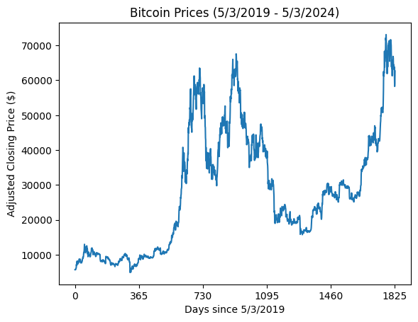

```python
plt.plot(range(len(crypto_price)), crypto_price)

plt.title("Bitcoin Prices (5/3/2019 - 5/3/2024)")
plt.xlabel("Days since 5/3/2019")
plt.xticks(range(0, len(crypto_price), 365))     #x -ticks every 365 days to represent a year from start date.
plt.ylabel("Adjusted Closing Price ($)")

plt.show()
```

The observation above is important to note because the extreme price fluctutations are characteristic of cryptocurrency's volatile nature. That being said, accurately predicting correct future prices proves to be a significant problem in Deep Learning. That is why it is important to start by overfitting the dataset, concoct a high-accuracy model, and improve on it by using augmentation and other Deep Learning techniques.

## Step 3: Create an overfitting model

### **3.1: Normalize the data with MinMaxScaler**

```python
scaler = MinMaxScaler(feature_range=(0, 1))
scaled_raw_data = scaler.fit_transform(raw_data)

target_scaler = MinMaxScaler(feature_range=(0, 1))
scaled_targets = target_scaler.fit_transform(crypto_price.reshape(-1, 1)).flatten()
```

### **3.2: Instantiate the dataset**

```python
all_sample_count = int(len(raw_data))
print("Number of samples in entire dataset:", all_sample_count)

sampling_rate = 1
sequence_length = 7
batch_size = 64

train_dataset = keras.utils.timeseries_dataset_from_array(
    scaled_raw_data,
    targets=scaled_targets,
    sampling_rate=sampling_rate,
    sequence_length=sequence_length,
    shuffle=True,
    batch_size=batch_size)
```

```
Number of samples in entire dataset: 1828
```

### **3.3: Create the model**

```python
model = keras.Sequential([
    layers.LSTM(6, input_shape=(sequence_length, raw_data.shape[-1]), return_sequences=True, activation="relu"),
    layers.LSTM(4, return_sequences=True, activation="relu"),
    layers.LSTM(2, activation="relu"),

    layers.Dense(1, activation="relu")
])
```

```python
model.summary()
```

```
Model: "sequential"
```

```
┏━━━━━━━━━━━━━━━━━━━━━━━━━━━━━━━━━┳━━━━━━━━━━━━━━━━━━━━━━━━┳━━━━━━━━━━━━━━━┓
┃ Layer (type)                    ┃ Output Shape           ┃       Param # ┃
┡━━━━━━━━━━━━━━━━━━━━━━━━━━━━━━━━━╇━━━━━━━━━━━━━━━━━━━━━━━━╇━━━━━━━━━━━━━━━┩
│ lstm (LSTM)                     │ (None, 7, 6)           │           312 │
├─────────────────────────────────┼────────────────────────┼───────────────┤
│ lstm_1 (LSTM)                   │ (None, 7, 4)           │           176 │
├─────────────────────────────────┼────────────────────────┼───────────────┤
│ lstm_2 (LSTM)                   │ (None, 2)              │            56 │
├─────────────────────────────────┼────────────────────────┼───────────────┤
│ dense (Dense)                   │ (None, 1)              │             3 │
└─────────────────────────────────┴────────────────────────┴───────────────┘
```

```
 Total params: 547 (2.14 KB)
```

```
 Trainable params: 547 (2.14 KB)
```

```
 Non-trainable params: 0 (0.00 B)
```

### **3.4: Compile and run the model**

```python
model.compile(optimizer="adam", loss="mse", metrics=["mae", "mse", "RootMeanSquaredError"])
history = model.fit(train_dataset,
                    epochs=100)
```

```
29/29 ━━━━━━━━━━━━━━━━━━━━ 10s 134ms/step - RootMeanSquaredError: 0.4240 - loss: 0.1798 - mae: 0.3415 - mse: 0.1798
29/29 ━━━━━━━━━━━━━━━━━━━━ 1s 17ms/step - RootMeanSquaredError: 0.4044 - loss: 0.1637 - mae: 0.3185 - mse: 0.1637
29/29 ━━━━━━━━━━━━━━━━━━━━ 0s 11ms/step - RootMeanSquaredError: 0.3518 - loss: 0.1239 - mae: 0.2688 - mse: 0.1239
29/29 ━━━━━━━━━━━━━━━━━━━━ 0s 9ms/step - RootMeanSquaredError: 0.2691 - loss: 0.0729 - mae: 0.2081 - mse: 0.0729
29/29 ━━━━━━━━━━━━━━━━━━━━ 0s 9ms/step - RootMeanSquaredError: 0.1151 - loss: 0.0133 - mae: 0.0906 - mse: 0.0133
29/29 ━━━━━━━━━━━━━━━━━━━━ 0s 10ms/step - RootMeanSquaredError: 0.0821 - loss: 0.0068 - mae: 0.0639 - mse: 0.0068
29/29 ━━━━━━━━━━━━━━━━━━━━ 1s 22ms/step - RootMeanSquaredError: 0.0634 - loss: 0.0040 - mae: 0.0475 - mse: 0.0040
29/29 ━━━━━━━━━━━━━━━━━━━━ 0s 10ms/step - RootMeanSquaredError: 0.0514 - loss: 0.0026 - mae: 0.0387 - mse: 0.0026
29/29 ━━━━━━━━━━━━━━━━━━━━ 0s 9ms/step - RootMeanSquaredError: 0.0314 - loss: 9.8972e-04 - mae: 0.0239 - mse: 9.8972e-04
29/29 ━━━━━━━━━━━━━━━━━━━━ 0s 9ms/step - RootMeanSquaredError: 0.0203 - loss: 4.1074e-04 - mae: 0.0156 - mse: 4.1074e-04
29/29 ━━━━━━━━━━━━━━━━━━━━ 1s 18ms/step - RootMeanSquaredError: 0.0166 - loss: 2.7732e-04 - mae: 0.0123 - mse: 2.7732e-04
29/29 ━━━━━━━━━━━━━━━━━━━━ 0s 9ms/step - RootMeanSquaredError: 0.0148 - loss: 2.2068e-04 - mae: 0.0106 - mse: 2.2068e-04
29/29 ━━━━━━━━━━━━━━━━━━━━ 0s 10ms/step - RootMeanSquaredError: 0.0142 - loss: 2.0177e-04 - mae: 0.0098 - mse: 2.0177e-04
29/29 ━━━━━━━━━━━━━━━━━━━━ 0s 9ms/step - RootMeanSquaredError: 0.0138 - loss: 1.9121e-04 - mae: 0.0096 - mse: 1.9121e-04
29/29 ━━━━━━━━━━━━━━━━━━━━ 0s 8ms/step - RootMeanSquaredError: 0.0138 - loss: 1.8945e-04 - mae: 0.0092 - mse: 1.8945e-04
29/29 ━━━━━━━━━━━━━━━━━━━━ 0s 10ms/step - RootMeanSquaredError: 0.0132 - loss: 1.7528e-04 - mae: 0.0091 - mse: 1.7528e-04
29/29 ━━━━━━━━━━━━━━━━━━━━ 0s 9ms/step - RootMeanSquaredError: 0.0131 - loss: 1.7195e-04 - mae: 0.0088 - mse: 1.7195e-04
29/29 ━━━━━━━━━━━━━━━━━━━━ 0s 8ms/step - RootMeanSquaredError: 0.0135 - loss: 1.8156e-04 - mae: 0.0091 - mse: 1.8156e-04
29/29 ━━━━━━━━━━━━━━━━━━━━ 0s 10ms/step - RootMeanSquaredError: 0.0129 - loss: 1.6686e-04 - mae: 0.0085 - mse: 1.6686e-04
29/29 ━━━━━━━━━━━━━━━━━━━━ 0s 9ms/step - RootMeanSquaredError: 0.0130 - loss: 1.6862e-04 - mae: 0.0088 - mse: 1.6862e-04
29/29 ━━━━━━━━━━━━━━━━━━━━ 0s 9ms/step - RootMeanSquaredError: 0.0128 - loss: 1.6486e-04 - mae: 0.0087 - mse: 1.6486e-04
29/29 ━━━━━━━━━━━━━━━━━━━━ 0s 10ms/step - RootMeanSquaredError: 0.0130 - loss: 1.6827e-04 - mae: 0.0088 - mse: 1.6827e-04
29/29 ━━━━━━━━━━━━━━━━━━━━ 0s 9ms/step - RootMeanSquaredError: 0.0124 - loss: 1.5518e-04 - mae: 0.0083 - mse: 1.5518e-04
29/29 ━━━━━━━━━━━━━━━━━━━━ 0s 9ms/step - RootMeanSquaredError: 0.0133 - loss: 1.7619e-04 - mae: 0.0090 - mse: 1.7619e-04
29/29 ━━━━━━━━━━━━━━━━━━━━ 0s 10ms/step - RootMeanSquaredError: 0.0132 - loss: 1.7448e-04 - mae: 0.0089 - mse: 1.7448e-04
29/29 ━━━━━━━━━━━━━━━━━━━━ 0s 9ms/step - RootMeanSquaredError: 0.0126 - loss: 1.5972e-04 - mae: 0.0084 - mse: 1.5972e-04
29/29 ━━━━━━━━━━━━━━━━━━━━ 0s 9ms/step - RootMeanSquaredError: 0.0125 - loss: 1.5686e-04 - mae: 0.0084 - mse: 1.5686e-04
29/29 ━━━━━━━━━━━━━━━━━━━━ 1s 9ms/step - RootMeanSquaredError: 0.0135 - loss: 1.8163e-04 - mae: 0.0091 - mse: 1.8163e-04
29/29 ━━━━━━━━━━━━━━━━━━━━ 1s 16ms/step - RootMeanSquaredError: 0.0128 - loss: 1.6323e-04 - mae: 0.0085 - mse: 1.6323e-04
29/29 ━━━━━━━━━━━━━━━━━━━━ 1s 14ms/step - RootMeanSquaredError: 0.0124 - loss: 1.5478e-04 - mae: 0.0083 - mse: 1.5478e-04
29/29 ━━━━━━━━━━━━━━━━━━━━ 1s 16ms/step - RootMeanSquaredError: 0.0125 - loss: 1.5758e-04 - mae: 0.0085 - mse: 1.5758e-04
29/29 ━━━━━━━━━━━━━━━━━━━━ 1s 16ms/step - RootMeanSquaredError: 0.0120 - loss: 1.4525e-04 - mae: 0.0080 - mse: 1.4525e-04
29/29 ━━━━━━━━━━━━━━━━━━━━ 1s 18ms/step - RootMeanSquaredError: 0.0124 - loss: 1.5449e-04 - mae: 0.0085 - mse: 1.5449e-04
29/29 ━━━━━━━━━━━━━━━━━━━━ 1s 11ms/step - RootMeanSquaredError: 0.0131 - loss: 1.7116e-04 - mae: 0.0090 - mse: 1.7116e-04
29/29 ━━━━━━━━━━━━━━━━━━━━ 0s 9ms/step - RootMeanSquaredError: 0.0121 - loss: 1.4613e-04 - mae: 0.0081 - mse: 1.4613e-04
29/29 ━━━━━━━━━━━━━━━━━━━━ 0s 10ms/step - RootMeanSquaredError: 0.0120 - loss: 1.4423e-04 - mae: 0.0080 - mse: 1.4423e-04
29/29 ━━━━━━━━━━━━━━━━━━━━ 0s 9ms/step - RootMeanSquaredError: 0.0123 - loss: 1.5022e-04 - mae: 0.0082 - mse: 1.5022e-04
29/29 ━━━━━━━━━━━━━━━━━━━━ 0s 9ms/step - RootMeanSquaredError: 0.0123 - loss: 1.5252e-04 - mae: 0.0082 - mse: 1.5252e-04
29/29 ━━━━━━━━━━━━━━━━━━━━ 0s 9ms/step - RootMeanSquaredError: 0.0123 - loss: 1.5026e-04 - mae: 0.0081 - mse: 1.5026e-04
29/29 ━━━━━━━━━━━━━━━━━━━━ 0s 10ms/step - RootMeanSquaredError: 0.0122 - loss: 1.4775e-04 - mae: 0.0080 - mse: 1.4775e-04
```

[output cut: 45 more lines]

```
29/29 ━━━━━━━━━━━━━━━━━━━━ 0s 10ms/step - RootMeanSquaredError: 0.0107 - loss: 1.1363e-04 - mae: 0.0073 - mse: 1.1363e-04
29/29 ━━━━━━━━━━━━━━━━━━━━ 0s 10ms/step - RootMeanSquaredError: 0.0105 - loss: 1.0939e-04 - mae: 0.0071 - mse: 1.0939e-04
29/29 ━━━━━━━━━━━━━━━━━━━━ 0s 10ms/step - RootMeanSquaredError: 0.0104 - loss: 1.0905e-04 - mae: 0.0072 - mse: 1.0905e-04
29/29 ━━━━━━━━━━━━━━━━━━━━ 0s 9ms/step - RootMeanSquaredError: 0.0105 - loss: 1.1120e-04 - mae: 0.0071 - mse: 1.1120e-04
29/29 ━━━━━━━━━━━━━━━━━━━━ 0s 11ms/step - RootMeanSquaredError: 0.0111 - loss: 1.2419e-04 - mae: 0.0077 - mse: 1.2419e-04
29/29 ━━━━━━━━━━━━━━━━━━━━ 0s 14ms/step - RootMeanSquaredError: 0.0103 - loss: 1.0583e-04 - mae: 0.0069 - mse: 1.0583e-04
29/29 ━━━━━━━━━━━━━━━━━━━━ 1s 17ms/step - RootMeanSquaredError: 0.0100 - loss: 9.9480e-05 - mae: 0.0068 - mse: 9.9480e-05
29/29 ━━━━━━━━━━━━━━━━━━━━ 1s 17ms/step - RootMeanSquaredError: 0.0113 - loss: 1.2836e-04 - mae: 0.0079 - mse: 1.2836e-04
29/29 ━━━━━━━━━━━━━━━━━━━━ 1s 17ms/step - RootMeanSquaredError: 0.0102 - loss: 1.0362e-04 - mae: 0.0068 - mse: 1.0362e-04
29/29 ━━━━━━━━━━━━━━━━━━━━ 1s 17ms/step - RootMeanSquaredError: 0.0113 - loss: 1.2705e-04 - mae: 0.0076 - mse: 1.2705e-04
29/29 ━━━━━━━━━━━━━━━━━━━━ 1s 17ms/step - RootMeanSquaredError: 0.0120 - loss: 1.4457e-04 - mae: 0.0084 - mse: 1.4457e-04
29/29 ━━━━━━━━━━━━━━━━━━━━ 1s 22ms/step - RootMeanSquaredError: 0.0119 - loss: 1.4278e-04 - mae: 0.0084 - mse: 1.4278e-04
29/29 ━━━━━━━━━━━━━━━━━━━━ 0s 11ms/step - RootMeanSquaredError: 0.0101 - loss: 1.0118e-04 - mae: 0.0070 - mse: 1.0118e-04
29/29 ━━━━━━━━━━━━━━━━━━━━ 0s 11ms/step - RootMeanSquaredError: 0.0102 - loss: 1.0386e-04 - mae: 0.0070 - mse: 1.0386e-04
29/29 ━━━━━━━━━━━━━━━━━━━━ 0s 10ms/step - RootMeanSquaredError: 0.0117 - loss: 1.3689e-04 - mae: 0.0077 - mse: 1.3689e-04
```

### **3.5: Graphically analyze the results/metrics**

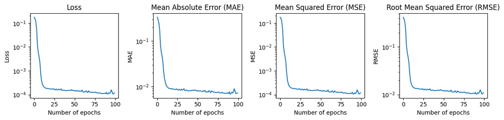

```python
import matplotlib.pyplot as plt

fig, axes = plt.subplots(1, 4, figsize=(12, 3))

axes[0].plot(history.history['loss'])
axes[0].set_title('Loss')
axes[0].set_xlabel('Number of epochs')
axes[0].set_ylabel('Loss')
axes[0].set_yscale('log')

axes[1].plot(history.history['mae'])
axes[1].set_title("Mean Absolute Error (MAE)")
axes[1].set_xlabel('Number of epochs')
axes[1].set_ylabel('MAE')
axes[1].set_yscale('log')

axes[2].plot(history.history['mse'])
axes[2].set_title("Mean Squared Error (MSE)")
axes[2].set_xlabel('Number of epochs')
axes[2].set_ylabel('MSE')
axes[2].set_yscale('log')

axes[3].plot(history.history['RootMeanSquaredError'])
axes[3].set_title("Root Mean Squared Error (RMSE)")
axes[3].set_xlabel('Number of epochs')
axes[3].set_ylabel('RMSE')
axes[3].set_yscale('log')

plt.tight_layout()
plt.show()
```

## Step 4: Divide the data into training, validation, and test sets

For the next phase of Bitcoin price predictions, the model must create predictions while allowing the analysis of three different phases: training, validation, and testing. For this reason, The BTC_USD.csv data must be divided into three datasets that reflect the three phases. This step allows a more thorough and accurate analysis of the model's performance.

### **4.1: Calculate and display the number of samples**

The entire **BTC_USD.csv** dataset contains 1,828 rows of data. The data was divided into three sets:

> 1. Training set (60% of the entire set).
> 2. Validation set (20% of the entire set).
> 3. Test set (20% of the entire set).

The **training set** will represent *seen* data, whereas the **validation** and **test sets** will represent *unnseen* data. For this reason, the data rows in the csv file will all contain unique data in separate folders to prevent *data leaking*.

Also, each dataset contains data that is based on timeliness. This measure was taken to maximize the effectiveness of the model as it attempts to predict cryptocurrency prices. The breakdown of data is as follows:

> 1.) The **training set** contains Bitcoin pricing data between 5/3/2019 and 5/2/2022.

> 2.) The **validation set** contains data between 5/3/2022 and 5/2/2023.

> 3.) The **test set** contains data between 5/3/2023 and 5/3/2024.

```python
training_sample_count = int(0.6 * len(raw_data))
validation_sample_count = int(0.2 * len(raw_data))
test_sample_count = len(raw_data) - training_sample_count - validation_sample_count

all_sample_count = training_sample_count + validation_sample_count + test_sample_count

print("Number of samples in entire dataset:", all_sample_count)

print("\nNumber of training samples:", training_sample_count)
print("Number of validation samples:", validation_sample_count)
print("Number of test samples:", test_sample_count)
```

```
Number of samples in entire dataset: 1828

Number of training samples: 1096
Number of validation samples: 365
Number of test samples: 367
```

**Visualizing the number of samples in each dataset**

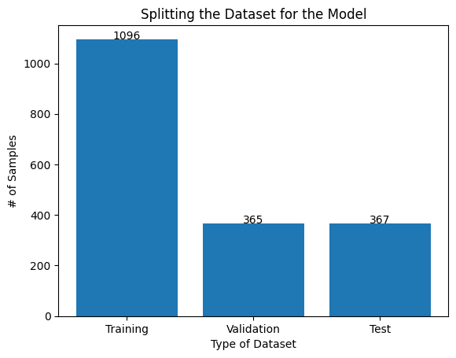

```python
data_type = ['Training', 'Validation', 'Test']
number_of_samples = [training_sample_count, validation_sample_count, test_sample_count]

plt.bar(data_type, number_of_samples)

plt.title('Splitting the Dataset for the Model')
plt.xlabel('Type of Dataset')
plt.ylabel('# of Samples')

for i in range(len(data_type)):
    plt.text(i, number_of_samples[i] + 1, str(number_of_samples[i]), ha='center')
```

### **4.2: Determine whether the Bitcoin training, validation, and test set connections are proper**

For each dataset, the Linux command **ls -l [filepath]** is used once more to verify whether they are connected to the Google Colab notebook. This process must be successful before creating an optimal model.

```python
! ls -l /content/drive/MyDrive/BTC_USD/
```

```
total 312
-rw------- 1 root root 159031 Mar  6 22:40 all_data.csv
-rw------- 1 root root  32296 Mar  6 22:40 test_data.csv
-rw------- 1 root root  94660 Mar  6 22:40 training_data.csv
-rw------- 1 root root  32158 Mar  6 22:40 validation_data.csv
```

### **4.3: Verify that each dataset works**

**The training set:**

```python
training_data = pd.read_csv("/content/drive/MyDrive/BTC_USD/training_data.csv", names = ['Date', 'Open', 'High', 'Low', 'Close', 'Adj Close', 'Volume'])

training_data.iloc[1:8]
```

|  | Date | Open | High | Low | Close | Adj Close | Volume |
| --- | --- | --- | --- | --- | --- | --- | --- |
| 1 | 2019-05-03 | 5505.552246 | 5865.881836 | 5490.201660 | 5768.289551 | 5768.289551 | 18720780006 |
| 2 | 2019-05-04 | 5769.202637 | 5886.893555 | 5645.469238 | 5831.167480 | 5831.167480 | 17567780766 |
| 3 | 2019-05-05 | 5831.068359 | 5833.862793 | 5708.035156 | 5795.708496 | 5795.708496 | 14808830723 |
| 4 | 2019-05-06 | 5791.693359 | 5802.957520 | 5653.687500 | 5746.807129 | 5746.807129 | 15737171804 |
| 5 | 2019-05-07 | 5745.599121 | 5988.178223 | 5741.395996 | 5829.501465 | 5829.501465 | 18026409033 |
| 6 | 2019-05-08 | 5849.481445 | 5989.980957 | 5794.715820 | 5982.457520 | 5982.457520 | 15320605300 |
| 7 | 2019-05-09 | 5982.316406 | 6183.039063 | 5982.316406 | 6174.528809 | 6174.528809 | 16784645411 |

**The validation set:**

```python
validation_data = pd.read_csv("/content/drive/MyDrive/BTC_USD/validation_data.csv", names = ['Date', 'Open', 'High', 'Low', 'Close', 'Adj Close', 'Volume'])

validation_data.iloc[1:8]
```

|  | Date | Open | High | Low | Close | Adj Close | Volume |
| --- | --- | --- | --- | --- | --- | --- | --- |
| 1 | 2022-05-03 | 38528.109375 | 38629.996094 | 37585.621094 | 37750.453125 | 37750.453125 | 27326943244 |
| 2 | 2022-05-04 | 37748.011719 | 39902.949219 | 37732.058594 | 39698.371094 | 39698.371094 | 36754404490 |
| 3 | 2022-05-05 | 39695.746094 | 39789.281250 | 35856.515625 | 36575.140625 | 36575.140625 | 43106256317 |
| 4 | 2022-05-06 | 36573.183594 | 36624.359375 | 35482.132813 | 36040.921875 | 36040.921875 | 37795577489 |
| 5 | 2022-05-07 | 36042.503906 | 36129.925781 | 34940.824219 | 35501.953125 | 35501.953125 | 24375896406 |
| 6 | 2022-05-08 | 35502.941406 | 35502.941406 | 33878.964844 | 34059.265625 | 34059.265625 | 36763041910 |
| 7 | 2022-05-09 | 34060.015625 | 34222.074219 | 30296.953125 | 30296.953125 | 30296.953125 | 63355494961 |

**The test set:**

```python
test_data = pd.read_csv("/content/drive/MyDrive/BTC_USD/test_data.csv", names = ['Date', 'Open', 'High', 'Low', 'Close', 'Adj Close', 'Volume'])

test_data.iloc[1:8]
```

|  | Date | Open | High | Low | Close | Adj Close | Volume |
| --- | --- | --- | --- | --- | --- | --- | --- |
| 1 | 2023-05-03 | 28680.494141 | 29259.533203 | 28178.388672 | 29006.308594 | 29006.308594 | 19122972518 |
| 2 | 2023-05-04 | 29031.304688 | 29353.185547 | 28694.039063 | 28847.710938 | 28847.710938 | 15548678514 |
| 3 | 2023-05-05 | 28851.480469 | 29668.908203 | 28845.509766 | 29534.384766 | 29534.384766 | 17936566518 |
| 4 | 2023-05-06 | 29538.859375 | 29820.126953 | 28468.966797 | 28904.623047 | 28904.623047 | 15913866714 |
| 5 | 2023-05-07 | 28901.623047 | 29157.517578 | 28441.367188 | 28454.978516 | 28454.978516 | 11301355486 |
| 6 | 2023-05-08 | 28450.457031 | 28663.271484 | 27310.134766 | 27694.273438 | 27694.273438 | 19122903752 |
| 7 | 2023-05-09 | 27695.068359 | 27821.400391 | 27375.601563 | 27658.775391 | 27658.775391 | 14128593256 |

## Step 5: Create an optimal model

### **5.1: Normalize the data with MinMaxScaler**

```python
scaler = MinMaxScaler(feature_range=(0, 1))
scaled_raw_data = scaler.fit_transform(raw_data)

target_scaler = MinMaxScaler(feature_range=(0, 1))
scaled_targets = target_scaler.fit_transform(crypto_price.reshape(-1, 1)).flatten()
```

### **5.2: Instantiate the training, validation, and test datasets**

```python
sampling_rate = 1
sequence_length = 7
delay = sampling_rate * (sequence_length + 24 - 1)
batch_size = 64

training_set = keras.utils.timeseries_dataset_from_array(
    scaled_raw_data[:-delay],
    targets=scaled_targets[delay:],
    sampling_rate=sampling_rate,
    sequence_length=sequence_length,
    shuffle=True,
    batch_size=batch_size,
    start_index=0,
    end_index=all_sample_count - delay - 1)

validation_set = keras.utils.timeseries_dataset_from_array(
    scaled_raw_data[:-delay],
    targets=scaled_targets[delay:],
    sampling_rate=sampling_rate,
    sequence_length=sequence_length,
    shuffle=True,
    batch_size=batch_size,
    start_index=all_sample_count - validation_sample_count - delay,
    end_index=all_sample_count - delay - 1)

test_set = keras.utils.timeseries_dataset_from_array(
    scaled_raw_data[:-delay],
    targets=scaled_targets[delay:],
    sampling_rate=sampling_rate,
    sequence_length=sequence_length,
    shuffle=True,
    batch_size=batch_size,
    start_index=training_sample_count + validation_sample_count)

print("\nNumber of training samples:", training_sample_count)
print("Number of validation samples:", validation_sample_count)
print("Number of test samples:", test_sample_count)
```

```
Number of training samples: 1096
Number of validation samples: 365
Number of test samples: 367
```

### **5.3: Visualize the shapes for samples and targets**

```python
for samples, targets in training_set:
     print("samples shape:", samples.shape)
     print("targets shape:", targets.shape)
     break
```

```
samples shape: (64, 7, 6)
targets shape: (64,)
```

### **5.4: Determine a common baseline for MAE, MSE, and RMSE**

```python
def evaluate_naive_method(dataset):
    total_abs_err = 0.
    total_squared_err = 0.
    samples_seen = 0
    for samples, targets in dataset:
        preds_normalized = samples[:, -1, 1]

        abs_err = np.abs(preds_normalized - targets)
        squared_err = (preds_normalized - targets) ** 2

        total_abs_err += np.sum(abs_err)
        total_squared_err += np.sum(squared_err)

        samples_seen += samples.shape[0]

    mae = total_abs_err / samples_seen
    mse = total_squared_err / samples_seen
    rmse = np.sqrt(mse)

    return mae, mse, rmse

val_mae, val_mse, val_rmse = evaluate_naive_method(validation_set)
test_mae, test_mse, test_rmse = evaluate_naive_method(test_set)

print(f"Validation MAE: {val_mae:.2f}")
print(f"Validation MSE: {val_mse:.2f}")
print(f"Validation RMSE: {val_rmse:.2f}")

print(f"\nTest MAE: {test_mae:.2f}")
print(f"Test MSE: {test_mse:.2f}")
print(f"Test RMSE: {test_rmse:.2f}")
```

```
Validation MAE: 0.06
Validation MSE: 0.01
Validation RMSE: 0.09

Test MAE: 0.06
Test MSE: 0.01
Test RMSE: 0.09
```

### **5.5: Create the model**

```python
model = keras.Sequential([
    layers.LSTM(40, input_shape=(sequence_length, raw_data.shape[-1]), return_sequences=True, activation="relu"),
    layers.LSTM(20, return_sequences=True, activation="relu"),
    layers.LSTM(10, activation="relu"),

    layers.Dense(1, activation="relu")
])

callbacks = [
    keras.callbacks.ModelCheckpoint("bitcoin_lstm.keras",
                                    save_best_only=True)
]
```

```python
model.summary()
```

```
Model: "sequential_1"
```

```
┏━━━━━━━━━━━━━━━━━━━━━━━━━━━━━━━━━┳━━━━━━━━━━━━━━━━━━━━━━━━┳━━━━━━━━━━━━━━━┓
┃ Layer (type)                    ┃ Output Shape           ┃       Param # ┃
┡━━━━━━━━━━━━━━━━━━━━━━━━━━━━━━━━━╇━━━━━━━━━━━━━━━━━━━━━━━━╇━━━━━━━━━━━━━━━┩
│ lstm_3 (LSTM)                   │ (None, 7, 40)          │         7,520 │
├─────────────────────────────────┼────────────────────────┼───────────────┤
│ lstm_4 (LSTM)                   │ (None, 7, 20)          │         4,880 │
├─────────────────────────────────┼────────────────────────┼───────────────┤
│ lstm_5 (LSTM)                   │ (None, 10)             │         1,240 │
├─────────────────────────────────┼────────────────────────┼───────────────┤
│ dense_1 (Dense)                 │ (None, 1)              │            11 │
└─────────────────────────────────┴────────────────────────┴───────────────┘
```

```
 Total params: 13,651 (53.32 KB)
```

```
 Trainable params: 13,651 (53.32 KB)
```

```
 Non-trainable params: 0 (0.00 B)
```

### **5.6: Compile and run the model**

```python
early_stopping = EarlyStopping(monitor='val_loss',
                               patience=20,
                               restore_best_weights=True)

model.compile(optimizer="adamax", loss="mse", metrics=["mae", "mse", "RootMeanSquaredError"])

history = model.fit(training_set,
                    epochs= 200,
                    validation_data=validation_set,
                    callbacks=[callbacks, early_stopping])

model = keras.models.load_model("bitcoin_lstm.keras")

input_data = np.random.random((1, sequence_length, raw_data.shape[-1]))  # Adjust according to your sequence length

predicted_prices = []
predicted_changes = []

# This loop is responsible for making day-by-day cryptocurrency predictions.
for _ in range(7):
    next_day_change = model.predict(input_data)
    predicted_changes.append(next_day_change[0, 0])

    next_input_data = np.roll(input_data, -1, axis=1)
    next_input_data[0, -1] = next_day_change

    # Update the input data for the next prediction
    input_data = next_input_data

# Reshape the predicted changes array to match the shape of the original scaled data
predicted_changes_reshaped = np.array(predicted_changes).reshape(-1, 1)
predicted_changes_repeated = np.repeat(predicted_changes_reshaped, 6, axis=1)

predicted_prices = scaler.inverse_transform(predicted_changes_repeated)

for i, price in enumerate(predicted_prices, start=1):
    print(f"Day {i}: ${price[4]:.2f}")  # The Adjusted Closing Price is at index 4 (column 5 of table)
```

```
28/28 ━━━━━━━━━━━━━━━━━━━━ 12s 182ms/step - RootMeanSquaredError: 0.3885 - loss: 0.1512 - mae: 0.3068 - mse: 0.1512 - val_RootMeanSquaredError: 0.3651 - val_loss: 0.1333 - val_mae: 0.3209 - val_mse: 0.1333
28/28 ━━━━━━━━━━━━━━━━━━━━ 0s 14ms/step - RootMeanSquaredError: 0.2299 - loss: 0.0538 - mae: 0.1724 - mse: 0.0538 - val_RootMeanSquaredError: 0.0970 - val_loss: 0.0094 - val_mae: 0.0729 - val_mse: 0.0094
28/28 ━━━━━━━━━━━━━━━━━━━━ 0s 11ms/step - RootMeanSquaredError: 0.1234 - loss: 0.0152 - mae: 0.1066 - mse: 0.0152 - val_RootMeanSquaredError: 0.1187 - val_loss: 0.0141 - val_mae: 0.0810 - val_mse: 0.0141
28/28 ━━━━━━━━━━━━━━━━━━━━ 0s 12ms/step - RootMeanSquaredError: 0.1091 - loss: 0.0119 - mae: 0.0893 - mse: 0.0119 - val_RootMeanSquaredError: 0.1065 - val_loss: 0.0113 - val_mae: 0.0714 - val_mse: 0.0113
28/28 ━━━━━━━━━━━━━━━━━━━━ 0s 13ms/step - RootMeanSquaredError: 0.1033 - loss: 0.0107 - mae: 0.0821 - mse: 0.0107 - val_RootMeanSquaredError: 0.1005 - val_loss: 0.0101 - val_mae: 0.0700 - val_mse: 0.0101
28/28 ━━━━━━━━━━━━━━━━━━━━ 0s 14ms/step - RootMeanSquaredError: 0.0982 - loss: 0.0097 - mae: 0.0755 - mse: 0.0097 - val_RootMeanSquaredError: 0.0964 - val_loss: 0.0093 - val_mae: 0.0694 - val_mse: 0.0093
28/28 ━━━━━━━━━━━━━━━━━━━━ 1s 18ms/step - RootMeanSquaredError: 0.0924 - loss: 0.0085 - mae: 0.0674 - mse: 0.0085 - val_RootMeanSquaredError: 0.0994 - val_loss: 0.0099 - val_mae: 0.0717 - val_mse: 0.0099
28/28 ━━━━━━━━━━━━━━━━━━━━ 1s 23ms/step - RootMeanSquaredError: 0.0891 - loss: 0.0080 - mae: 0.0623 - mse: 0.0080 - val_RootMeanSquaredError: 0.0960 - val_loss: 0.0092 - val_mae: 0.0698 - val_mse: 0.0092
28/28 ━━━━━━━━━━━━━━━━━━━━ 1s 19ms/step - RootMeanSquaredError: 0.0878 - loss: 0.0077 - mae: 0.0609 - mse: 0.0077 - val_RootMeanSquaredError: 0.0973 - val_loss: 0.0095 - val_mae: 0.0711 - val_mse: 0.0095
28/28 ━━━━━━━━━━━━━━━━━━━━ 1s 22ms/step - RootMeanSquaredError: 0.0910 - loss: 0.0083 - mae: 0.0633 - mse: 0.0083 - val_RootMeanSquaredError: 0.1038 - val_loss: 0.0108 - val_mae: 0.0743 - val_mse: 0.0108
28/28 ━━━━━━━━━━━━━━━━━━━━ 1s 21ms/step - RootMeanSquaredError: 0.0882 - loss: 0.0078 - mae: 0.0605 - mse: 0.0078 - val_RootMeanSquaredError: 0.0983 - val_loss: 0.0097 - val_mae: 0.0712 - val_mse: 0.0097
28/28 ━━━━━━━━━━━━━━━━━━━━ 0s 15ms/step - RootMeanSquaredError: 0.0909 - loss: 0.0083 - mae: 0.0623 - mse: 0.0083 - val_RootMeanSquaredError: 0.0933 - val_loss: 0.0087 - val_mae: 0.0680 - val_mse: 0.0087
28/28 ━━━━━━━━━━━━━━━━━━━━ 0s 12ms/step - RootMeanSquaredError: 0.0892 - loss: 0.0080 - mae: 0.0622 - mse: 0.0080 - val_RootMeanSquaredError: 0.0963 - val_loss: 0.0093 - val_mae: 0.0694 - val_mse: 0.0093
28/28 ━━━━━━━━━━━━━━━━━━━━ 0s 12ms/step - RootMeanSquaredError: 0.0882 - loss: 0.0078 - mae: 0.0611 - mse: 0.0078 - val_RootMeanSquaredError: 0.0943 - val_loss: 0.0089 - val_mae: 0.0683 - val_mse: 0.0089
28/28 ━━━━━━━━━━━━━━━━━━━━ 0s 12ms/step - RootMeanSquaredError: 0.0883 - loss: 0.0078 - mae: 0.0615 - mse: 0.0078 - val_RootMeanSquaredError: 0.0933 - val_loss: 0.0087 - val_mae: 0.0672 - val_mse: 0.0087
28/28 ━━━━━━━━━━━━━━━━━━━━ 0s 13ms/step - RootMeanSquaredError: 0.0878 - loss: 0.0077 - mae: 0.0609 - mse: 0.0077 - val_RootMeanSquaredError: 0.0942 - val_loss: 0.0089 - val_mae: 0.0672 - val_mse: 0.0089
28/28 ━━━━━━━━━━━━━━━━━━━━ 0s 13ms/step - RootMeanSquaredError: 0.0878 - loss: 0.0077 - mae: 0.0611 - mse: 0.0077 - val_RootMeanSquaredError: 0.0966 - val_loss: 0.0093 - val_mae: 0.0694 - val_mse: 0.0093
28/28 ━━━━━━━━━━━━━━━━━━━━ 0s 12ms/step - RootMeanSquaredError: 0.0884 - loss: 0.0078 - mae: 0.0618 - mse: 0.0078 - val_RootMeanSquaredError: 0.0991 - val_loss: 0.0098 - val_mae: 0.0705 - val_mse: 0.0098
28/28 ━━━━━━━━━━━━━━━━━━━━ 0s 14ms/step - RootMeanSquaredError: 0.0872 - loss: 0.0076 - mae: 0.0605 - mse: 0.0076 - val_RootMeanSquaredError: 0.1104 - val_loss: 0.0122 - val_mae: 0.0770 - val_mse: 0.0122
28/28 ━━━━━━━━━━━━━━━━━━━━ 0s 12ms/step - RootMeanSquaredError: 0.0909 - loss: 0.0083 - mae: 0.0632 - mse: 0.0083 - val_RootMeanSquaredError: 0.0972 - val_loss: 0.0095 - val_mae: 0.0685 - val_mse: 0.0095
```

[output cut: 26 more lines]

### **5.7: Graphically analyze the results/metrics**

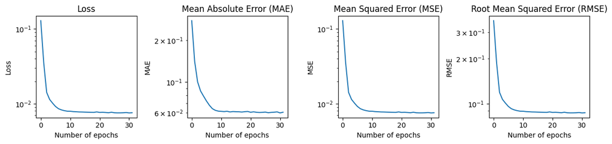

```python
import matplotlib.pyplot as plt

fig, axes = plt.subplots(1, 4, figsize=(12, 3))

axes[0].plot(history.history['loss'])
axes[0].set_title('Loss')
axes[0].set_xlabel('Number of epochs')
axes[0].set_ylabel('Loss')
axes[0].set_yscale('log')

axes[1].plot(history.history['mae'])
axes[1].set_title("Mean Absolute Error (MAE)")
axes[1].set_xlabel('Number of epochs')
axes[1].set_ylabel('MAE')
axes[1].set_yscale('log')

axes[2].plot(history.history['mse'])
axes[2].set_title("Mean Squared Error (MSE)")
axes[2].set_xlabel('Number of epochs')
axes[2].set_ylabel('MSE')
axes[2].set_yscale('log')

axes[3].plot(history.history['RootMeanSquaredError'])
axes[3].set_title("Root Mean Squared Error (RMSE)")
axes[3].set_xlabel('Number of epochs')
axes[3].set_ylabel('RMSE')
axes[3].set_yscale('log')

plt.tight_layout()
plt.show()
```

## Step 6: Apply data augmentation to the model

### **6.1: Create and compile a model with Time Shifting:**

#### **a.) Create shifted data**

```python
shift_range = range(-3, 4)  # Shift data by -3 to +3 time steps

def generate_time_shifted_data(data, targets, sequence_length, shift_range):
    shifted_data, shifted_targets = [], []
    for shift in shift_range:
        shifted_data.append(np.roll(data, shift, axis=0))
        shifted_targets.append(np.roll(targets, shift, axis=0))
    shifted_data = np.concatenate(shifted_data)
    shifted_targets = np.concatenate(shifted_targets)
    return shifted_data[:len(data)], shifted_targets[:len(targets)]
```

#### **b.) Instantiate training, validation, and test datasets**

```python
sampling_rate = 1
sequence_length = 7
shift_range = range(-3, 4)  # Shift data by -3 to +3 time steps
delay = sampling_rate * (sequence_length + 24 - 1)
batch_size = 64

# Training data
X_train_shifted, y_train_shifted = generate_time_shifted_data(scaled_raw_data[:-delay], scaled_targets[delay:], sequence_length, shift_range)

#  Validation data
X_val_shifted, y_val_shifted = generate_time_shifted_data(scaled_raw_data[:-delay], scaled_targets[delay:], sequence_length, shift_range)
val_start_index = all_sample_count - validation_sample_count - delay
X_val_shifted = X_val_shifted[val_start_index:]
y_val_shifted = y_val_shifted[val_start_index:]

# Test data
X_test_shifted, y_test_shifted = generate_time_shifted_data(scaled_raw_data[:-delay], scaled_targets[delay:], sequence_length, shift_range)
test_start_index = training_sample_count + validation_sample_count
X_test_shifted = X_test_shifted[test_start_index:]
y_test_shifted = y_test_shifted[test_start_index:]

training_set = keras.utils.timeseries_dataset_from_array(
    X_train_shifted,
    targets=y_train_shifted,
    sampling_rate=sampling_rate,
    sequence_length=sequence_length,
    shuffle=True,
    batch_size=batch_size,
    start_index=0,
    end_index=len(X_train_shifted) - 1
)

validation_set = keras.utils.timeseries_dataset_from_array(
    X_val_shifted,
    targets=y_val_shifted,
    sampling_rate=sampling_rate,
    sequence_length=sequence_length,
    shuffle=True,
    batch_size=batch_size,
    start_index=0,
    end_index=len(X_val_shifted) - 1
)

test_set = keras.utils.timeseries_dataset_from_array(
    X_test_shifted,
    targets=y_test_shifted,
    sampling_rate=sampling_rate,
    sequence_length=sequence_length,
    shuffle=True,
    batch_size=batch_size,
    start_index=0,
    end_index=len(X_test_shifted) - 1
)

print("\nNumber of training samples:", len(X_train_shifted))
print("Number of validation samples:", len(X_val_shifted))
print("Number of test samples:", len(X_test_shifted))
```

```
Number of training samples: 1798
Number of validation samples: 365
Number of test samples: 337
```

#### **c.) Construct the model**

```python
model = keras.Sequential([
    layers.LSTM(40, input_shape=(sequence_length, raw_data.shape[-1]), return_sequences=True, activation="relu"),
    layers.LSTM(20, return_sequences=True, activation="relu"),
    layers.LSTM(10, activation="relu"),

    layers.Dense(1, activation="relu")
])

callbacks = [
    keras.callbacks.ModelCheckpoint("bitcoin_lstm.keras",
                                    save_best_only=True)]

model = keras.Sequential([
    layers.LSTM(40, input_shape=(sequence_length, scaled_raw_data.shape[-1]), return_sequences=True, activation="relu"),
    layers.LSTM(20, return_sequences=True, activation="relu"),
    layers.LSTM(10, activation="relu"),
    layers.Dense(1, activation="relu")
])
```

#### **d.) Compile and run the model**

```python
model.compile(optimizer="adamax", loss="mse", metrics=["mae", "mse", "RootMeanSquaredError"])

history = model.fit(training_set,
                    epochs= 200,
                    validation_data=validation_set,
                    callbacks=[callbacks, early_stopping])

model = keras.models.load_model("bitcoin_lstm.keras")

input_data = np.random.random((1, sequence_length, raw_data.shape[-1]))  # Adjust according to your sequence length

predicted_prices = []
predicted_changes = []

# This loop is responsible for making day-by-day cryptocurrency predictions.
for _ in range(7):
    next_day_change = model.predict(input_data)
    predicted_changes.append(next_day_change[0, 0])

    next_input_data = np.roll(input_data, -1, axis=1)
    next_input_data[0, -1] = next_day_change

    # Update the input data for the next prediction
    input_data = next_input_data

# Reshape the predicted changes array to match the shape of the original scaled data
predicted_changes_reshaped = np.array(predicted_changes).reshape(-1, 1)
predicted_changes_repeated = np.repeat(predicted_changes_reshaped, 6, axis=1)

predicted_prices = scaler.inverse_transform(predicted_changes_repeated)

for i, price in enumerate(predicted_prices, start=1):
    print(f"Day {i}: ${price[4]:.2f}")  # The Adjusted Closing Price is at index 4 (column 5 of table)

time_shifting_loss = history.history['loss']
time_shifting_mae = history.history['mae']
time_shifting_mse = history.history['mse']
time_shifting_rmse = history.history['RootMeanSquaredError']
```

```
28/28 ━━━━━━━━━━━━━━━━━━━━ 12s 211ms/step - RootMeanSquaredError: 0.3775 - loss: 0.1432 - mae: 0.2976 - mse: 0.1432 - val_RootMeanSquaredError: 0.3102 - val_loss: 0.0962 - val_mae: 0.2727 - val_mse: 0.0962
28/28 ━━━━━━━━━━━━━━━━━━━━ 1s 15ms/step - RootMeanSquaredError: 0.1738 - loss: 0.0309 - mae: 0.1312 - mse: 0.0309 - val_RootMeanSquaredError: 0.1206 - val_loss: 0.0146 - val_mae: 0.0835 - val_mse: 0.0146
28/28 ━━━━━━━━━━━━━━━━━━━━ 0s 14ms/step - RootMeanSquaredError: 0.1169 - loss: 0.0137 - mae: 0.0928 - mse: 0.0137 - val_RootMeanSquaredError: 0.1160 - val_loss: 0.0135 - val_mae: 0.0802 - val_mse: 0.0135
28/28 ━━━━━━━━━━━━━━━━━━━━ 0s 13ms/step - RootMeanSquaredError: 0.1107 - loss: 0.0123 - mae: 0.0873 - mse: 0.0123 - val_RootMeanSquaredError: 0.1196 - val_loss: 0.0143 - val_mae: 0.0833 - val_mse: 0.0143
28/28 ━━━━━━━━━━━━━━━━━━━━ 0s 14ms/step - RootMeanSquaredError: 0.1074 - loss: 0.0115 - mae: 0.0817 - mse: 0.0115 - val_RootMeanSquaredError: 0.1143 - val_loss: 0.0131 - val_mae: 0.0788 - val_mse: 0.0131
28/28 ━━━━━━━━━━━━━━━━━━━━ 0s 14ms/step - RootMeanSquaredError: 0.1002 - loss: 0.0100 - mae: 0.0732 - mse: 0.0100 - val_RootMeanSquaredError: 0.1074 - val_loss: 0.0115 - val_mae: 0.0747 - val_mse: 0.0115
28/28 ━━━━━━━━━━━━━━━━━━━━ 0s 15ms/step - RootMeanSquaredError: 0.0962 - loss: 0.0092 - mae: 0.0676 - mse: 0.0092 - val_RootMeanSquaredError: 0.1055 - val_loss: 0.0111 - val_mae: 0.0720 - val_mse: 0.0111
28/28 ━━━━━━━━━━━━━━━━━━━━ 0s 15ms/step - RootMeanSquaredError: 0.0940 - loss: 0.0088 - mae: 0.0660 - mse: 0.0088 - val_RootMeanSquaredError: 0.1005 - val_loss: 0.0101 - val_mae: 0.0684 - val_mse: 0.0101
28/28 ━━━━━━━━━━━━━━━━━━━━ 0s 15ms/step - RootMeanSquaredError: 0.0926 - loss: 0.0086 - mae: 0.0641 - mse: 0.0086 - val_RootMeanSquaredError: 0.0952 - val_loss: 0.0091 - val_mae: 0.0680 - val_mse: 0.0091
28/28 ━━━━━━━━━━━━━━━━━━━━ 0s 13ms/step - RootMeanSquaredError: 0.0903 - loss: 0.0082 - mae: 0.0626 - mse: 0.0082 - val_RootMeanSquaredError: 0.0964 - val_loss: 0.0093 - val_mae: 0.0691 - val_mse: 0.0093
28/28 ━━━━━━━━━━━━━━━━━━━━ 1s 15ms/step - RootMeanSquaredError: 0.0893 - loss: 0.0080 - mae: 0.0619 - mse: 0.0080 - val_RootMeanSquaredError: 0.0942 - val_loss: 0.0089 - val_mae: 0.0686 - val_mse: 0.0089
28/28 ━━━━━━━━━━━━━━━━━━━━ 0s 15ms/step - RootMeanSquaredError: 0.0900 - loss: 0.0081 - mae: 0.0631 - mse: 0.0081 - val_RootMeanSquaredError: 0.0942 - val_loss: 0.0089 - val_mae: 0.0683 - val_mse: 0.0089
28/28 ━━━━━━━━━━━━━━━━━━━━ 0s 13ms/step - RootMeanSquaredError: 0.0887 - loss: 0.0079 - mae: 0.0622 - mse: 0.0079 - val_RootMeanSquaredError: 0.0960 - val_loss: 0.0092 - val_mae: 0.0703 - val_mse: 0.0092
28/28 ━━━━━━━━━━━━━━━━━━━━ 1s 14ms/step - RootMeanSquaredError: 0.0905 - loss: 0.0082 - mae: 0.0631 - mse: 0.0082 - val_RootMeanSquaredError: 0.0936 - val_loss: 0.0088 - val_mae: 0.0683 - val_mse: 0.0088
28/28 ━━━━━━━━━━━━━━━━━━━━ 0s 13ms/step - RootMeanSquaredError: 0.0895 - loss: 0.0080 - mae: 0.0628 - mse: 0.0080 - val_RootMeanSquaredError: 0.0973 - val_loss: 0.0095 - val_mae: 0.0707 - val_mse: 0.0095
28/28 ━━━━━━━━━━━━━━━━━━━━ 0s 13ms/step - RootMeanSquaredError: 0.0899 - loss: 0.0081 - mae: 0.0626 - mse: 0.0081 - val_RootMeanSquaredError: 0.0941 - val_loss: 0.0089 - val_mae: 0.0689 - val_mse: 0.0089
28/28 ━━━━━━━━━━━━━━━━━━━━ 0s 13ms/step - RootMeanSquaredError: 0.0912 - loss: 0.0083 - mae: 0.0640 - mse: 0.0083 - val_RootMeanSquaredError: 0.0995 - val_loss: 0.0099 - val_mae: 0.0718 - val_mse: 0.0099
28/28 ━━━━━━━━━━━━━━━━━━━━ 1s 16ms/step - RootMeanSquaredError: 0.0894 - loss: 0.0080 - mae: 0.0626 - mse: 0.0080 - val_RootMeanSquaredError: 0.0998 - val_loss: 0.0100 - val_mae: 0.0715 - val_mse: 0.0100
28/28 ━━━━━━━━━━━━━━━━━━━━ 0s 12ms/step - RootMeanSquaredError: 0.0888 - loss: 0.0079 - mae: 0.0619 - mse: 0.0079 - val_RootMeanSquaredError: 0.0998 - val_loss: 0.0100 - val_mae: 0.0714 - val_mse: 0.0100
28/28 ━━━━━━━━━━━━━━━━━━━━ 0s 14ms/step - RootMeanSquaredError: 0.0905 - loss: 0.0082 - mae: 0.0629 - mse: 0.0082 - val_RootMeanSquaredError: 0.0882 - val_loss: 0.0078 - val_mae: 0.0652 - val_mse: 0.0078
28/28 ━━━━━━━━━━━━━━━━━━━━ 0s 14ms/step - RootMeanSquaredError: 0.0903 - loss: 0.0082 - mae: 0.0636 - mse: 0.0082 - val_RootMeanSquaredError: 0.0928 - val_loss: 0.0086 - val_mae: 0.0689 - val_mse: 0.0086
28/28 ━━━━━━━━━━━━━━━━━━━━ 1s 16ms/step - RootMeanSquaredError: 0.0878 - loss: 0.0077 - mae: 0.0618 - mse: 0.0077 - val_RootMeanSquaredError: 0.0950 - val_loss: 0.0090 - val_mae: 0.0690 - val_mse: 0.0090
28/28 ━━━━━━━━━━━━━━━━━━━━ 1s 20ms/step - RootMeanSquaredError: 0.0884 - loss: 0.0078 - mae: 0.0617 - mse: 0.0078 - val_RootMeanSquaredError: 0.1008 - val_loss: 0.0102 - val_mae: 0.0724 - val_mse: 0.0102
28/28 ━━━━━━━━━━━━━━━━━━━━ 1s 22ms/step - RootMeanSquaredError: 0.0896 - loss: 0.0080 - mae: 0.0626 - mse: 0.0080 - val_RootMeanSquaredError: 0.0928 - val_loss: 0.0086 - val_mae: 0.0677 - val_mse: 0.0086
28/28 ━━━━━━━━━━━━━━━━━━━━ 1s 21ms/step - RootMeanSquaredError: 0.0906 - loss: 0.0082 - mae: 0.0638 - mse: 0.0082 - val_RootMeanSquaredError: 0.0899 - val_loss: 0.0081 - val_mae: 0.0664 - val_mse: 0.0081
28/28 ━━━━━━━━━━━━━━━━━━━━ 1s 21ms/step - RootMeanSquaredError: 0.0903 - loss: 0.0082 - mae: 0.0625 - mse: 0.0082 - val_RootMeanSquaredError: 0.0950 - val_loss: 0.0090 - val_mae: 0.0694 - val_mse: 0.0090
```

[output cut: 65 more lines]

#### **e.) Evaluate the model**

```python
valid_loss, valid_MAE, valid_MSE, valid_RMSE = model.evaluate(validation_set, verbose=2)
```

```
6/6 - 2s - 370ms/step - RootMeanSquaredError: 0.0853 - loss: 0.0073 - mae: 0.0642 - mse: 0.0073
```

#### **a.) Create normalized data with MinMaxScaler**

```python
scaler = MinMaxScaler(feature_range=(0, 1))
scaled_raw_data = scaler.fit_transform(raw_data)

target_scaler = MinMaxScaler(feature_range=(0, 1))
scaled_targets = target_scaler.fit_transform(crypto_price.reshape(-1, 1)).flatten()
```

#### **b.) Instantiate training, validation, and test datasets**

```python
sampling_rate = 1
sequence_length = 7
shift_range = range(-3, 4)  # Shift data by -3 to +3 time steps
delay = sampling_rate * (sequence_length + 24 - 1)
batch_size = 64

scaled_raw_data = scaler.fit_transform(raw_data)
scaled_targets = tf.reshape(target_scaler.fit_transform(crypto_price.reshape(-1, 1)), -1)

# Function to add noise to data
def add_noise(data, noise_level=0.05):
    noise = np.random.normal(loc=0, scale=noise_level, size=data.shape)
    return data + noise

# Add noise to the scaled raw data
noisy_scaled_raw_data = add_noise(scaled_raw_data)

training_set = keras.utils.timeseries_dataset_from_array(
    scaled_raw_data[:-delay],
    targets=scaled_targets[delay:],
    sampling_rate=sampling_rate,
    sequence_length=sequence_length,
    shuffle=True,
    batch_size=batch_size,
    start_index=0,
    end_index=all_sample_count - delay - 1)

validation_set = keras.utils.timeseries_dataset_from_array(
    scaled_raw_data[:-delay],
    targets=scaled_targets[delay:],
    sampling_rate=sampling_rate,
    sequence_length=sequence_length,
    shuffle=True,
    batch_size=batch_size,
    start_index=all_sample_count - validation_sample_count - delay,
    end_index=all_sample_count - delay - 1)

test_set = keras.utils.timeseries_dataset_from_array(
    scaled_raw_data[:-delay],
    targets=scaled_targets[delay:],
    sampling_rate=sampling_rate,
    sequence_length=sequence_length,
    shuffle=True,
    batch_size=batch_size,
    start_index=training_sample_count + validation_sample_count)

print("\nNumber of training samples:", training_sample_count)
print("Number of validation samples:", validation_sample_count)
print("Number of test samples:", test_sample_count)
```

```
Number of training samples: 1096
Number of validation samples: 365
Number of test samples: 367
```

#### **c.) Construct the model**

```python
model = keras.Sequential([
    layers.LSTM(40, input_shape=(sequence_length, raw_data.shape[-1]), return_sequences=True, activation="relu"),
    layers.LSTM(20, return_sequences=True, activation="relu"),
    layers.LSTM(10, activation="relu"),

    layers.Dense(1, activation="relu")
])

callbacks = [
    keras.callbacks.ModelCheckpoint("bitcoin_lstm.keras",
                                    save_best_only=True)
]
```

#### **d.) Compile and run the model**

```python
early_stopping = EarlyStopping(monitor='val_loss',
                               patience=20,
                               restore_best_weights=True)

model.compile(optimizer="adamax", loss="mse", metrics=["mae", "mse", "RootMeanSquaredError"])

history = model.fit(training_set,
                    epochs= 200,
                    validation_data=validation_set,
                    callbacks=[callbacks, early_stopping])

model = keras.models.load_model("bitcoin_lstm.keras")

input_data = np.random.random((1, sequence_length, raw_data.shape[-1]))  # Adjust according to your sequence length

predicted_prices = []
predicted_changes = []

# This loop is responsible for making day-by-day cryptocurrency predictions.
for _ in range(7):
    next_day_change = model.predict(input_data)
    predicted_changes.append(next_day_change[0, 0])

    next_input_data = np.roll(input_data, -1, axis=1)
    next_input_data[0, -1] = next_day_change

    # Update the input data for the next prediction
    input_data = next_input_data

# Reshape the predicted changes array to match the shape of the original scaled data
predicted_changes_reshaped = np.array(predicted_changes).reshape(-1, 1)
predicted_changes_repeated = np.repeat(predicted_changes_reshaped, 6, axis=1)

predicted_prices = scaler.inverse_transform(predicted_changes_repeated)

for i, price in enumerate(predicted_prices, start=1):
    print(f"Day {i}: ${price[4]:.2f}")  # The Adjusted Closing Price is at index 4 (column 5 of table)

noise_injection_loss = history.history['loss']
noise_injection_mae = history.history['mae']
noise_injection_mse = history.history['mse']
noise_injection_rmse = history.history['RootMeanSquaredError']
```

```
28/28 ━━━━━━━━━━━━━━━━━━━━ 10s 190ms/step - RootMeanSquaredError: 0.4111 - loss: 0.1690 - mae: 0.3297 - mse: 0.1690 - val_RootMeanSquaredError: 0.4674 - val_loss: 0.2184 - val_mae: 0.4244 - val_mse: 0.2184
28/28 ━━━━━━━━━━━━━━━━━━━━ 1s 24ms/step - RootMeanSquaredError: 0.3201 - loss: 0.1029 - mae: 0.2434 - mse: 0.1029 - val_RootMeanSquaredError: 0.1721 - val_loss: 0.0296 - val_mae: 0.1385 - val_mse: 0.0296
28/28 ━━━━━━━━━━━━━━━━━━━━ 1s 15ms/step - RootMeanSquaredError: 0.1268 - loss: 0.0161 - mae: 0.0979 - mse: 0.0161 - val_RootMeanSquaredError: 0.1228 - val_loss: 0.0151 - val_mae: 0.0874 - val_mse: 0.0151
28/28 ━━━━━━━━━━━━━━━━━━━━ 0s 15ms/step - RootMeanSquaredError: 0.1054 - loss: 0.0111 - mae: 0.0831 - mse: 0.0111 - val_RootMeanSquaredError: 0.0995 - val_loss: 0.0099 - val_mae: 0.0713 - val_mse: 0.0099
28/28 ━━━━━━━━━━━━━━━━━━━━ 1s 14ms/step - RootMeanSquaredError: 0.1002 - loss: 0.0100 - mae: 0.0796 - mse: 0.0100 - val_RootMeanSquaredError: 0.0950 - val_loss: 0.0090 - val_mae: 0.0689 - val_mse: 0.0090
28/28 ━━━━━━━━━━━━━━━━━━━━ 0s 14ms/step - RootMeanSquaredError: 0.0975 - loss: 0.0095 - mae: 0.0758 - mse: 0.0095 - val_RootMeanSquaredError: 0.0939 - val_loss: 0.0088 - val_mae: 0.0691 - val_mse: 0.0088
28/28 ━━━━━━━━━━━━━━━━━━━━ 0s 12ms/step - RootMeanSquaredError: 0.0952 - loss: 0.0091 - mae: 0.0738 - mse: 0.0091 - val_RootMeanSquaredError: 0.1008 - val_loss: 0.0102 - val_mae: 0.0731 - val_mse: 0.0102
28/28 ━━━━━━━━━━━━━━━━━━━━ 0s 13ms/step - RootMeanSquaredError: 0.0943 - loss: 0.0089 - mae: 0.0723 - mse: 0.0089 - val_RootMeanSquaredError: 0.0996 - val_loss: 0.0099 - val_mae: 0.0722 - val_mse: 0.0099
28/28 ━━━━━━━━━━━━━━━━━━━━ 0s 13ms/step - RootMeanSquaredError: 0.0920 - loss: 0.0085 - mae: 0.0695 - mse: 0.0085 - val_RootMeanSquaredError: 0.0944 - val_loss: 0.0089 - val_mae: 0.0686 - val_mse: 0.0089
28/28 ━━━━━━━━━━━━━━━━━━━━ 0s 14ms/step - RootMeanSquaredError: 0.0881 - loss: 0.0078 - mae: 0.0659 - mse: 0.0078 - val_RootMeanSquaredError: 0.0899 - val_loss: 0.0081 - val_mae: 0.0651 - val_mse: 0.0081
28/28 ━━━━━━━━━━━━━━━━━━━━ 0s 14ms/step - RootMeanSquaredError: 0.0898 - loss: 0.0081 - mae: 0.0665 - mse: 0.0081 - val_RootMeanSquaredError: 0.0888 - val_loss: 0.0079 - val_mae: 0.0644 - val_mse: 0.0079
28/28 ━━━━━━━━━━━━━━━━━━━━ 0s 12ms/step - RootMeanSquaredError: 0.0887 - loss: 0.0079 - mae: 0.0644 - mse: 0.0079 - val_RootMeanSquaredError: 0.0946 - val_loss: 0.0090 - val_mae: 0.0668 - val_mse: 0.0090
28/28 ━━━━━━━━━━━━━━━━━━━━ 0s 13ms/step - RootMeanSquaredError: 0.0867 - loss: 0.0075 - mae: 0.0615 - mse: 0.0075 - val_RootMeanSquaredError: 0.1020 - val_loss: 0.0104 - val_mae: 0.0710 - val_mse: 0.0104
28/28 ━━━━━━━━━━━━━━━━━━━━ 0s 14ms/step - RootMeanSquaredError: 0.0861 - loss: 0.0074 - mae: 0.0612 - mse: 0.0074 - val_RootMeanSquaredError: 0.0857 - val_loss: 0.0074 - val_mae: 0.0626 - val_mse: 0.0074
28/28 ━━━━━━━━━━━━━━━━━━━━ 0s 13ms/step - RootMeanSquaredError: 0.0867 - loss: 0.0075 - mae: 0.0607 - mse: 0.0075 - val_RootMeanSquaredError: 0.0914 - val_loss: 0.0083 - val_mae: 0.0647 - val_mse: 0.0083
28/28 ━━━━━━━━━━━━━━━━━━━━ 0s 13ms/step - RootMeanSquaredError: 0.0841 - loss: 0.0071 - mae: 0.0588 - mse: 0.0071 - val_RootMeanSquaredError: 0.0910 - val_loss: 0.0083 - val_mae: 0.0647 - val_mse: 0.0083
28/28 ━━━━━━━━━━━━━━━━━━━━ 0s 12ms/step - RootMeanSquaredError: 0.0861 - loss: 0.0074 - mae: 0.0606 - mse: 0.0074 - val_RootMeanSquaredError: 0.0906 - val_loss: 0.0082 - val_mae: 0.0646 - val_mse: 0.0082
28/28 ━━━━━━━━━━━━━━━━━━━━ 0s 12ms/step - RootMeanSquaredError: 0.0859 - loss: 0.0074 - mae: 0.0598 - mse: 0.0074 - val_RootMeanSquaredError: 0.0935 - val_loss: 0.0087 - val_mae: 0.0664 - val_mse: 0.0087
28/28 ━━━━━━━━━━━━━━━━━━━━ 0s 12ms/step - RootMeanSquaredError: 0.0841 - loss: 0.0071 - mae: 0.0592 - mse: 0.0071 - val_RootMeanSquaredError: 0.0942 - val_loss: 0.0089 - val_mae: 0.0664 - val_mse: 0.0089
28/28 ━━━━━━━━━━━━━━━━━━━━ 0s 12ms/step - RootMeanSquaredError: 0.0852 - loss: 0.0073 - mae: 0.0590 - mse: 0.0073 - val_RootMeanSquaredError: 0.0950 - val_loss: 0.0090 - val_mae: 0.0671 - val_mse: 0.0090
28/28 ━━━━━━━━━━━━━━━━━━━━ 0s 13ms/step - RootMeanSquaredError: 0.0849 - loss: 0.0072 - mae: 0.0597 - mse: 0.0072 - val_RootMeanSquaredError: 0.0993 - val_loss: 0.0099 - val_mae: 0.0688 - val_mse: 0.0099
28/28 ━━━━━━━━━━━━━━━━━━━━ 0s 15ms/step - RootMeanSquaredError: 0.0862 - loss: 0.0074 - mae: 0.0599 - mse: 0.0074 - val_RootMeanSquaredError: 0.0850 - val_loss: 0.0072 - val_mae: 0.0622 - val_mse: 0.0072
28/28 ━━━━━━━━━━━━━━━━━━━━ 0s 12ms/step - RootMeanSquaredError: 0.0876 - loss: 0.0077 - mae: 0.0613 - mse: 0.0077 - val_RootMeanSquaredError: 0.0903 - val_loss: 0.0082 - val_mae: 0.0642 - val_mse: 0.0082
28/28 ━━━━━━━━━━━━━━━━━━━━ 0s 12ms/step - RootMeanSquaredError: 0.0835 - loss: 0.0070 - mae: 0.0590 - mse: 0.0070 - val_RootMeanSquaredError: 0.1017 - val_loss: 0.0103 - val_mae: 0.0698 - val_mse: 0.0103
28/28 ━━━━━━━━━━━━━━━━━━━━ 1s 22ms/step - RootMeanSquaredError: 0.0839 - loss: 0.0070 - mae: 0.0588 - mse: 0.0070 - val_RootMeanSquaredError: 0.0878 - val_loss: 0.0077 - val_mae: 0.0637 - val_mse: 0.0077
28/28 ━━━━━━━━━━━━━━━━━━━━ 1s 22ms/step - RootMeanSquaredError: 0.0827 - loss: 0.0068 - mae: 0.0584 - mse: 0.0068 - val_RootMeanSquaredError: 0.0976 - val_loss: 0.0095 - val_mae: 0.0681 - val_mse: 0.0095
```

[output cut: 79 more lines]

#### **e.) Evaluate the model**

```python
valid_loss, valid_MAE, valid_MSE, valid_RMSE = model.evaluate(validation_set, verbose=2)
```

```
6/6 - 3s - 520ms/step - RootMeanSquaredError: 0.0780 - loss: 0.0061 - mae: 0.0599 - mse: 0.0061
```